# EDA about orgn_program

```r
library(tidyverse)
library(lubridate)
library(dbplyr)
library(dbplot)
library(RPostgreSQL)
library(ggforce)
library(DT)

theme_set(theme_bw(base_family = "HiraKakuPro-W3"))
```

```r
conn <- dbConnect(PostgreSQL(),
                  host = scan("connection.txt", what = character())[1],
                  port = scan("connection.txt", what = character())[2],
                  dbname = scan("connection.txt", what = character())[3],
                  user = scan("connection.txt", what = character())[4],
                  password = scan("connection.txt", what = character())[5])

orgn <- conn %>%
  tbl(from = dbplyr::in_schema("edit", "tv_orgn_program_2"))
tmp <- conn %>%
  tbl(from = dbplyr::in_schema("processed", "tv_orgn_p_cv"))
program <- conn %>%
  tbl(from = dbplyr::in_schema("processed", "tv_program"))
ban <- conn %>%
  tbl(from = dbplyr::in_schema("processed", "bancluster_mst"))
ban1 <- conn %>%
  tbl(from = dbplyr::in_schema("sub_mst", "ban_code1_mst"))
prof_data <- conn %>%
  tbl(from = dbplyr::in_schema("processed", "profiledata"))
prof_mst <- conn %>%
  tbl(from = dbplyr::in_schema("processed", "profilemaster"))
prof <- prof_data %>%
  left_join(prof_mst, by = c("qu_genre_code", "question_code", "answer_code"))
```

# 1 introduction

テレビ接触の傾向をさぐる

**TV接触おさらい** タイムシフト or リアルタイムを問わず，再生された番組の放送局と放送日時のレコード．  
さらに，なんの番組を見ていたかに対応するorgn_programを稗田さんに作成していただいた

クラスタ（VR区分）との繋がりも探っていけたら良い

**注意点**  
processed.tv_orgn_p_cvが接触した放送部分のレコードであるのに対し  
edit.orgn_programでは番組を跨いだ視聴が分割されるので，注意が必要

# 2 count records

## 2.1 processed.tv_orgn_p_cv

- 細切れに分けて接触した場合はレコードが増える
- ぶっ通しで複数番組見た場合はレコードが一つになる
- リアルタイムがタイムシフトの約2倍ある

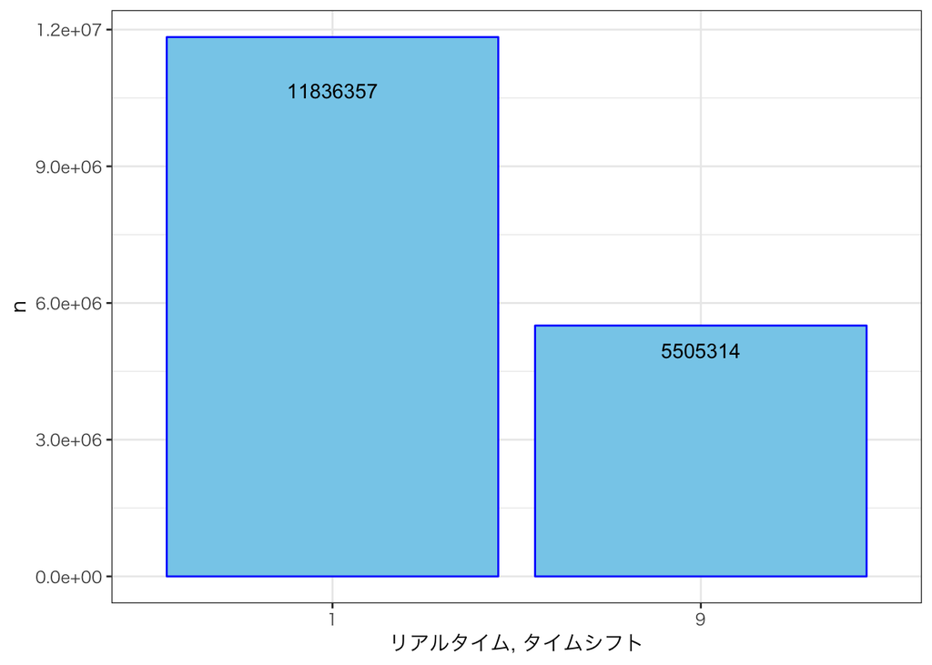

```r
tmp %>%
  count(data_agg_type) %>%
  arrange(data_agg_type) %>%
  ggplot(aes(factor(data_agg_type), n))+
  geom_bar(stat = "identity", colour = "blue", fill = "skyblue")+
  geom_text(aes(label = n, y = n*0.9))+
  labs(x = "リアルタイム, タイムシフト")
```

## 2.2 edit.orgn_program_2

- 番組との回数
- ぶっ通しで複数番組見た場合が切り分けられている
  - 当然，タイムシフトは番組ごとに予約して見ているはず
  - よってリアルタイムの方が爆発的に増える（約1.5倍）
  - タイムシフト視聴の方はほとんど変わらない（6万件増える）

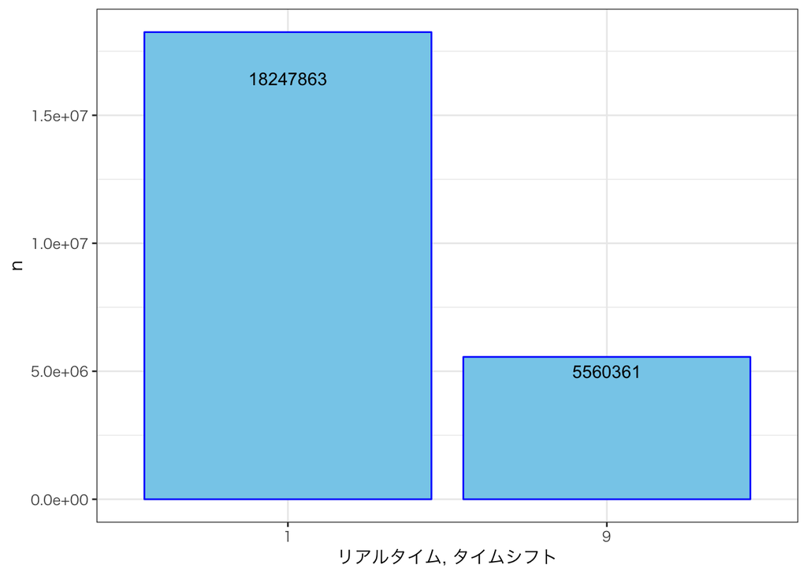

```r
orgn %>%
  count(data_agg_type) %>%
  arrange(data_agg_type) %>%
  ggplot(aes(factor(data_agg_type), n))+
  geom_bar(stat = "identity", colour = "blue", fill = "skyblue")+
  geom_text(aes(label = n, y = n*0.9))+
  labs(x = "リアルタイム, タイムシフト")
```

## 2.3 per ban_code1

- ドラマは録画して見る傾向が強い，などの傾向がありそう

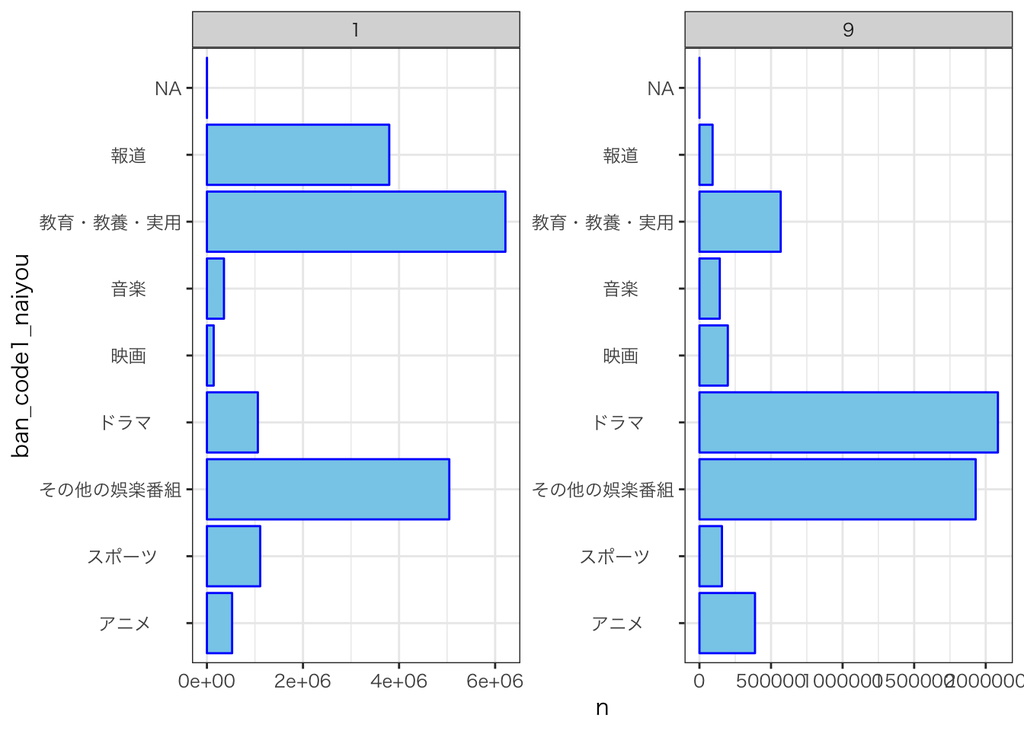

```r
orgn %>%
  left_join(program, by = c("program_code", "program_start_time")) %>%
  count(ban_code1, data_agg_type) %>%
  ungroup() %>%
  left_join(ban1, by = "ban_code1") %>%
  ggplot(aes(ban_code1_naiyou, n))+
  geom_bar(stat = "identity", colour = "blue", fill = "skyblue")+
  coord_flip()+
  facet_wrap(~data_agg_type, scale = "free")
```

続いて全体に占めるタイムシフトの比率を見てみる

- ドラマ，映画，アニメはタイムシフトで見る傾向が顕著
- 次点で音楽，娯楽番組
- 逆に報道，教育・教養・実用・スポーツはリアルタイムで見る傾向

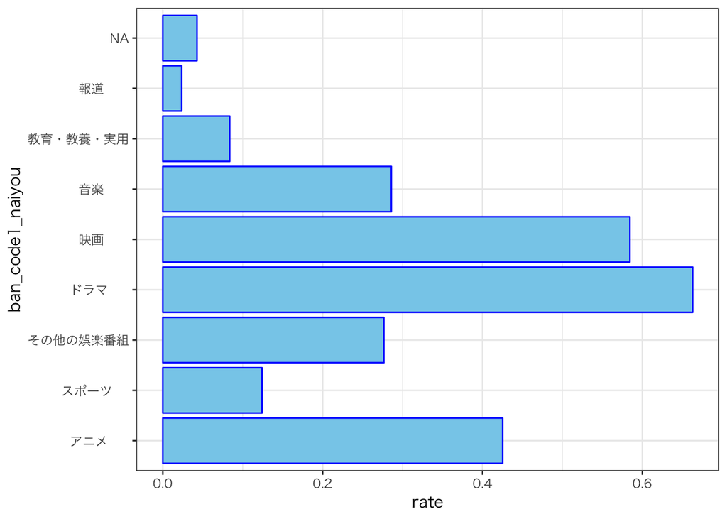

```r
orgn %>%
  left_join(program, by = c("program_code", "program_start_time")) %>%
  count(ban_code1, data_agg_type) %>%
  left_join(ban1, by = "ban_code1") %>%
  group_by(ban_code1_naiyou) %>%
  mutate(rate = n / sum(n, na.rm=TRUE)) %>%
  filter(data_agg_type == 9) %>%
  ggplot(aes(ban_code1_naiyou, rate))+
  geom_bar(stat = "identity", colour = "blue", fill = "skyblue")+
  coord_flip()
```

## 2.4 count records per program

```r
top5 <- orgn %>%
  select(house_num, program_start_time, station_code, data_agg_type) %>%
  left_join(program, by = c("program_start_time", "station_code")) %>%
  count(ban_code1, program_code, program_name) %>%
  ungroup() %>%
  group_by(ban_code1) %>%
  arrange(desc(n)) %>%
  collect()
top5 %>%
  slice(1:5) %>%
  ungroup() %>%
  left_join(collect(ban1), by = "ban_code1") %>%
  arrange(ban_code1_naiyou) %>%
  mutate(program_name = str_remove_all(program_name, pattern = " ")) %>%
  select(ban_code1_naiyou, program_name, n) %>%
  datatable()
```

|  | ban_code1_naiyou | program_name | n |
| --- | --- | --- | --- |
| 1 | アニメ | 名探偵コナン | 46648 |
| 2 | アニメ | ワンピース | 34350 |
| 3 | アニメ | パッコロリン | 32839 |
| 4 | アニメ | サザエさん | 32720 |
| 5 | アニメ | ドラゴンボール超 | 29438 |
| 6 | スポーツ | Ｇｏｉｎｇ！Ｓｐｏｒｔｓ＆Ｎｅｗｓ | 46423 |
| 7 | スポーツ | スポーツＬＩＦＥ ＨＥＲＯ’Ｓ | 30105 |
| 8 | スポーツ | 追跡ＬＩＶＥ！ＳＰＯＲＴＳウォッチャー | 25155 |
| 9 | スポーツ | 炎の体育会ＴＶ ＳＰ | 23267 |
| 10 | スポーツ | ピョンチャンオリンピック | 23138 |

[output cut: 31 more lines]

# 3 watch time

どのぐらいの時間番組を見たか 接触分(watch_time)ごとのレコード数をプロットした  
orgn_programを使用

- 指数分布に近い
- チャンネルを目まぐるしく変えている感じ？

## 3.1 watch_time distribution

- 指数分布っぽい？
- 2380万レコードのうち，500万レコードが1分以内

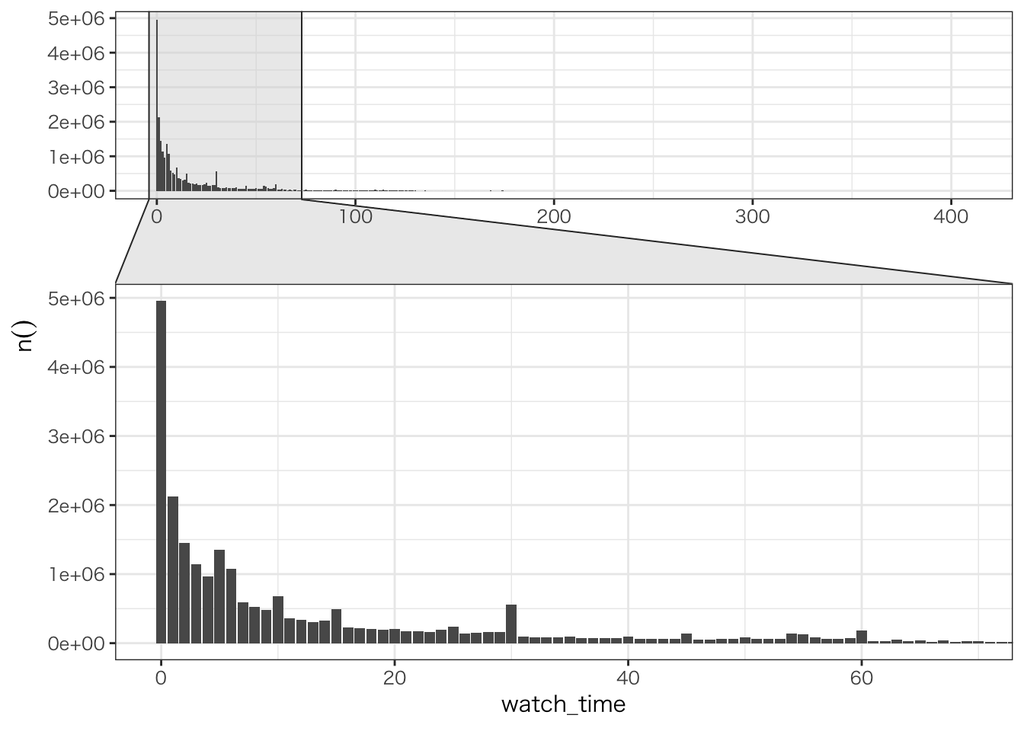

```r
orgn %>%
  dbplot_bar(watch_time)+
  facet_zoom(x = x < 70)
```

## 3.2 non zero watch_time distribution

- 指数分布っぽい
- 60分, 30分, 15分, 10分, 5分のスパイクが目立つ
- 番組を最初から最後まで見ているためだろうか？

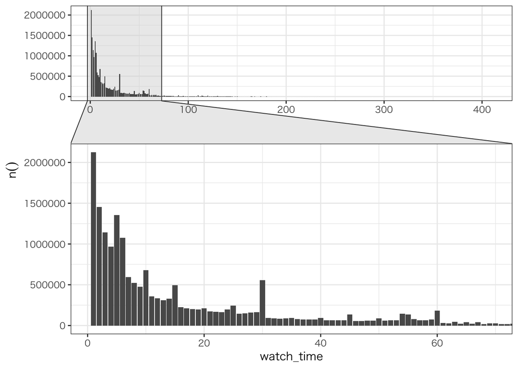

```r
orgn %>%
  filter(watch_time != 0) %>%
  dbplot_bar(watch_time)+
  facet_zoom(x = x < 70)
```

## 3.3 watch_time ratio

番組時間のうち，一回の接触がどのぐらいの割合かを見る

- リアルタイムは直感に合う
  - 番組を全部見るのが割とあって
  - 一瞬で他に変えるのが割とある
- タイムシフトが直感に合わない
  - CMを飛ばすため，割合1が少ないのは頷ける
  - 割合0がめちゃくちゃ多い理由がわからない
  - わざわざタイムシフト視聴してるのに
  - **CMを飛ばしたり巻き戻したりすると，別々のレコードとして記録される？？？**

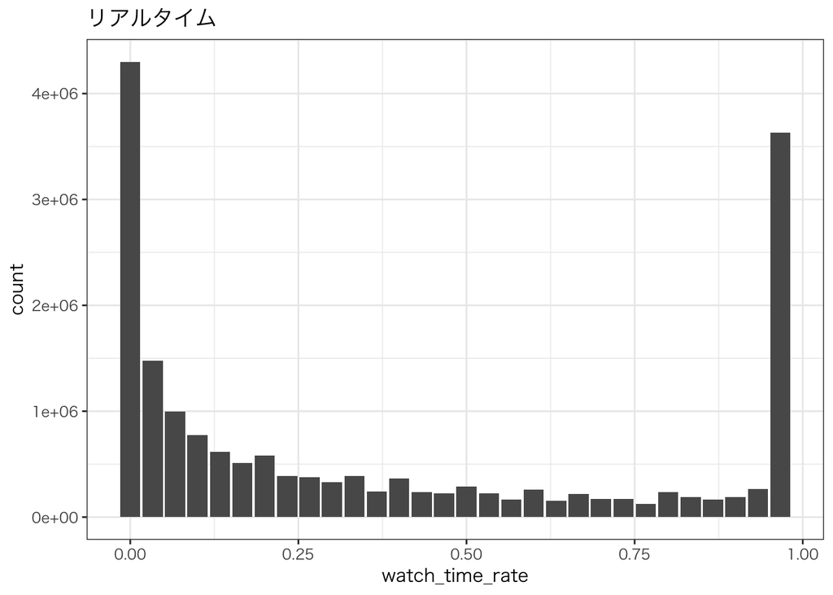

```r
orgn %>%
  mutate(watch_time_rate = watch_time / program_time) %>%
  filter(data_agg_type == 1) %>%
  dbplot_histogram(watch_time_rate)+
  labs(title = "リアルタイム")
```

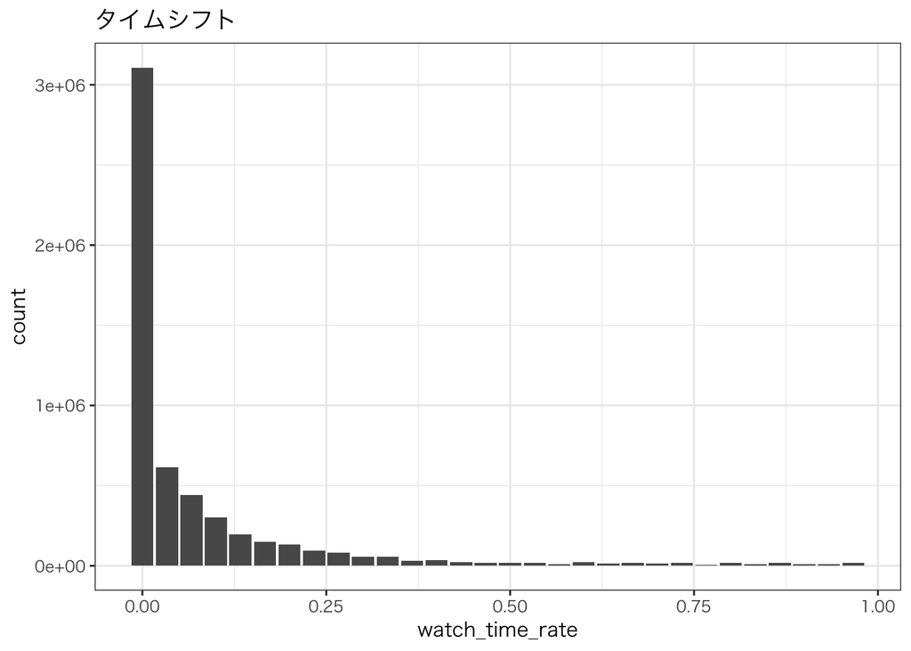

```r
orgn %>%
  mutate(watch_time_rate = watch_time / program_time) %>%
  filter(data_agg_type == 9) %>%
  dbplot_histogram(watch_time_rate)+
  labs(title = "タイムシフト")
```

## 3.4 raster plot watch_time and program_time

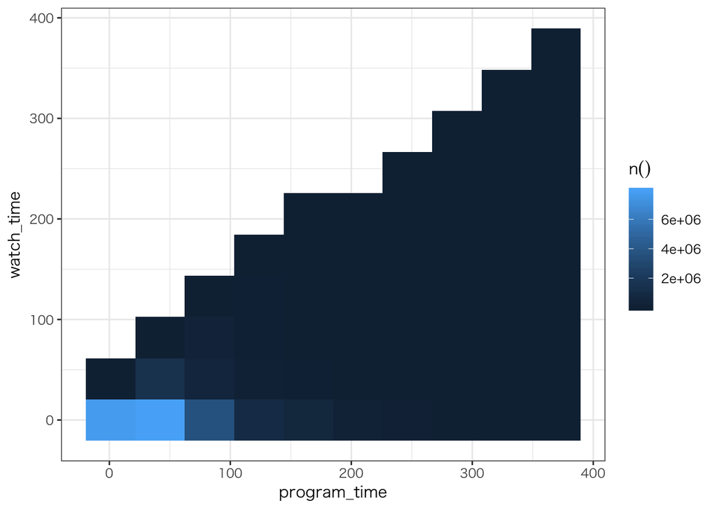

```r
orgn %>%
  mutate(watch_time_rate = watch_time / program_time) %>%
  dbplot_raster(program_time, watch_time, resolution = 10)+
  labs("all records")
```

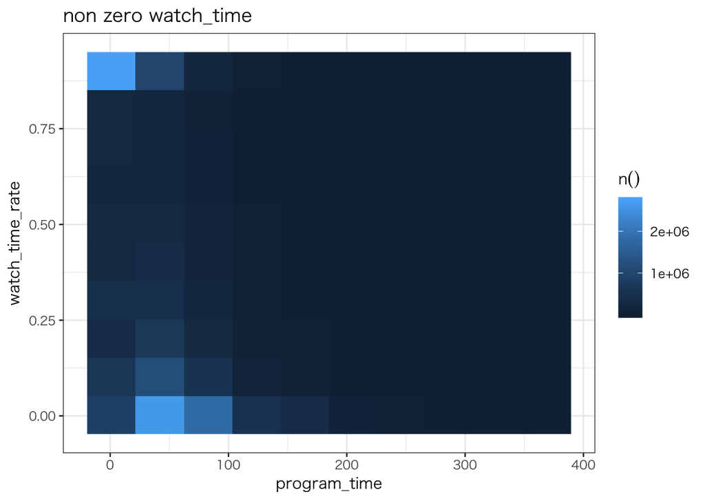

```r
orgn %>%
  filter(watch_time != 0) %>%
  mutate(watch_time_rate = watch_time / program_time) %>%
  dbplot_raster(program_time, watch_time_rate, resolution = 10)+
  labs(title = "non zero watch_time")
```

# 4 per house_num

## 4.1 sum watch_time

- 右に裾の広い分布
- 少数の世帯がかなりテレビを見る

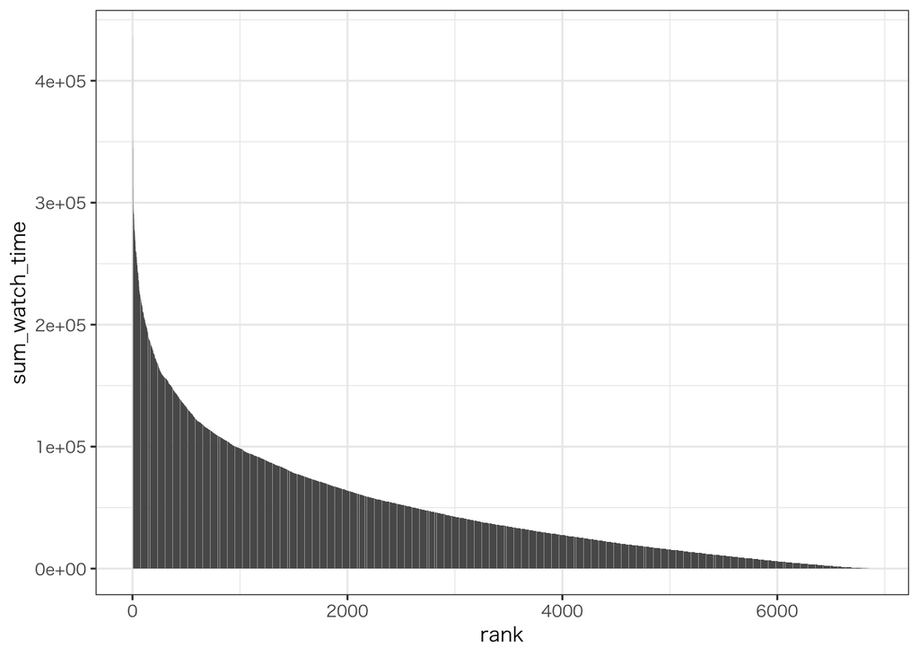

```r
orgn %>%
  group_by(house_num) %>%
  summarise(sum_watch_time = sum(watch_time)) %>%
  arrange(desc(sum_watch_time)) %>%
  collect() %>%
  mutate(rank = 1:n()) %>%
  ggplot(aes(rank, sum_watch_time))+
  geom_bar(stat = "identity")
```

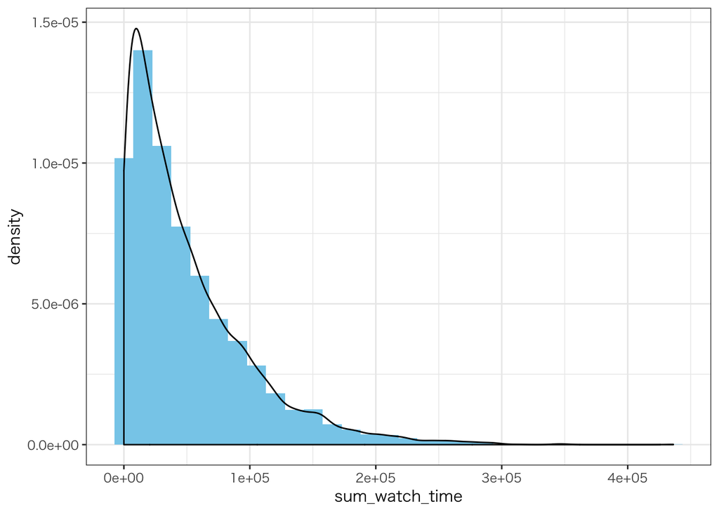

```r
orgn %>%
  group_by(house_num) %>%
  summarise(sum_watch_time = sum(watch_time)) %>%
  arrange(desc(sum_watch_time)) %>%
  collect() %>%
  ggplot(aes(sum_watch_time, ..density..))+
  geom_histogram( fill = "skyblue")+
  geom_density()
```

## 4.2 log sum watch_time

- ヒストグラムを見ると，明らかな異常値がある
- 全くテレビをみない世帯

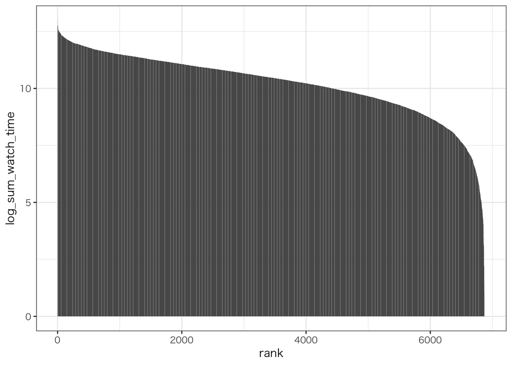

```r
orgn %>%
  group_by(house_num) %>%
  summarise(log_sum_watch_time = log(sum(watch_time)+1)) %>%
  arrange(desc(log_sum_watch_time)) %>%
  collect() %>%
  mutate(rank = 1:n()) %>%
  ggplot(aes(rank, log_sum_watch_time))+
  geom_bar(stat = "identity")
```

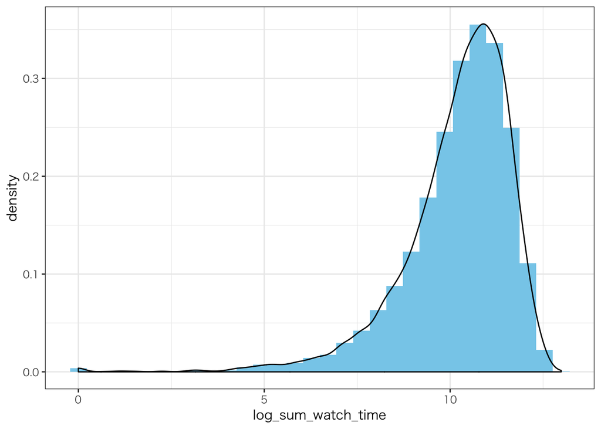

```r
orgn %>%
  group_by(house_num) %>%
  summarise(log_sum_watch_time = log(sum(watch_time)+1)) %>%
  collect() %>%
  ggplot(aes(log_sum_watch_time, ..density..))+
  geom_histogram(fill = "skyblue")+
  geom_density()
```

## 4.3 watch_time ratio

- オレンジが中央値で水色が平均値（世帯ごと）
- 基本的に **平均 > 中央値**であることから，どの世帯も基本的に**watch_time rateは右に裾が広い**

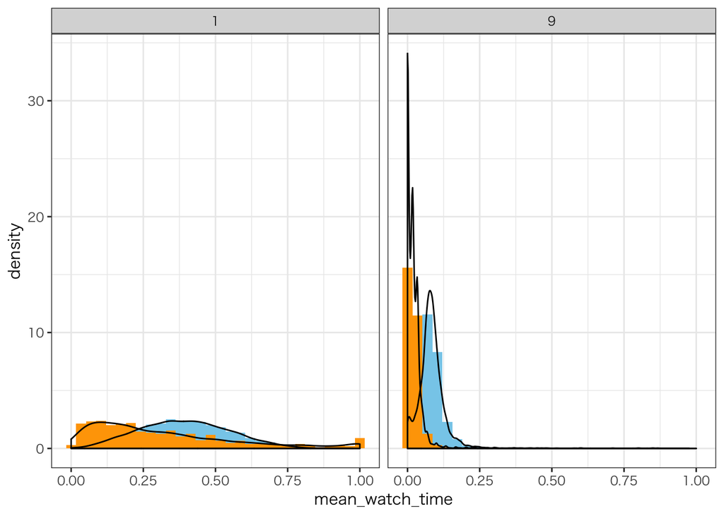

```r
orgn %>%
  group_by(house_num, data_agg_type) %>%
  summarise(mean_watch_time = mean(watch_time / program_time),
            median_watch_time = median(watch_time / program_time)) %>%
  ggplot(aes(mean_watch_time, ..density..))+
  geom_histogram(fill = "skyblue")+
  geom_histogram(aes(median_watch_time), fill = "orange")+
  geom_density()+
  geom_density(aes(median_watch_time))+
  facet_wrap(~data_agg_type)
```

# 5 per ban_code1

## 5.1 program_time distribution

programからとってきた

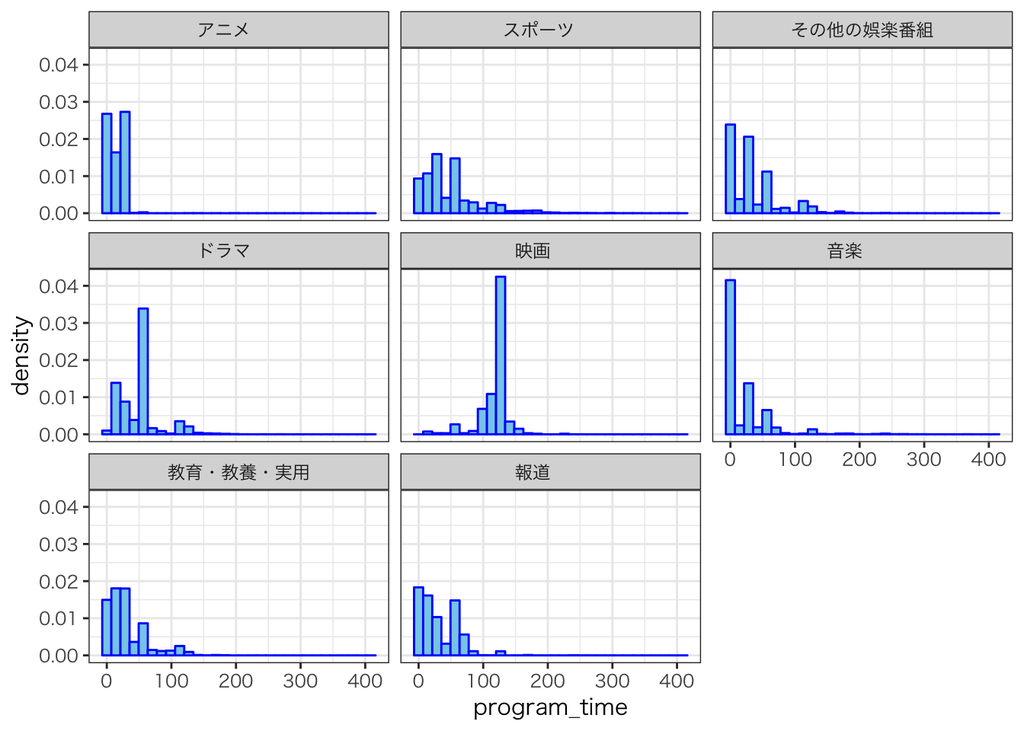

```r
program %>%
  left_join(ban1, by = "ban_code1") %>%
  collect() %>%
  select(ban_code1_naiyou, program_time) %>%
  ggplot(aes(program_time, ..density..))+
  geom_histogram(fill = "skyblue", colour = "blue")+
  facet_wrap(~ban_code1_naiyou)
```

## 5.2 watch_time summarise

- アニメ, 報道は偏りがあまりない．
- 右に裾が長くない
- つまりチャンネルチェンジされる確率が低いといえる

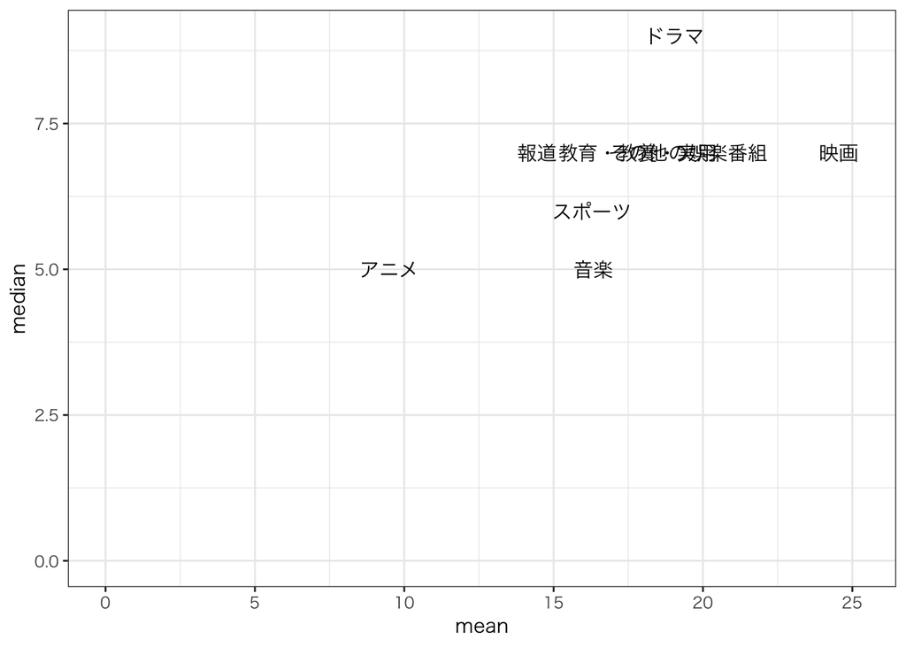

```r
orgn %>%
  filter(data_agg_type == 1) %>%
  select(program_code, program_start_time, watch_time) %>%
  left_join(program, by = c("program_code", "program_start_time")) %>%
  left_join(ban1, by = "ban_code1") %>%
  select(ban_code1_naiyou, watch_time) %>%
  group_by(ban_code1_naiyou) %>%
  summarise(mean = mean(watch_time),
            median = median(watch_time)) %>%
  ggplot(aes(x = mean, y = median))+
  geom_text(aes(label = ban_code1_naiyou), family = "HiraKakuPro-W3")
```

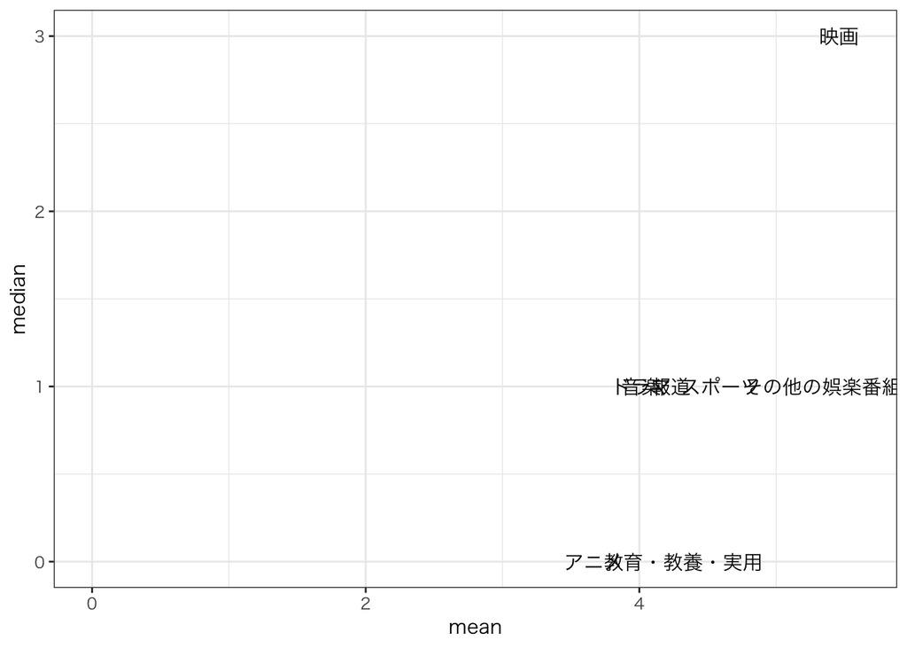

```r
orgn %>%
  filter(data_agg_type == 9) %>%
  select(program_code, program_start_time, watch_time) %>%
  left_join(program, by = c("program_code", "program_start_time")) %>%
  left_join(ban1, by = "ban_code1") %>%
  select(ban_code1_naiyou, watch_time) %>%
  group_by(ban_code1_naiyou) %>%
  summarise(mean = mean(watch_time),
            median = median(watch_time)) %>%
  ggplot(aes(x = mean, y = median))+
  geom_text(aes(label = ban_code1_naiyou), family = "HiraKakuPro-W3")
```

## 5.3 watch_time_rate

mean watch_time_rateを棒グラフで  
medianを点で

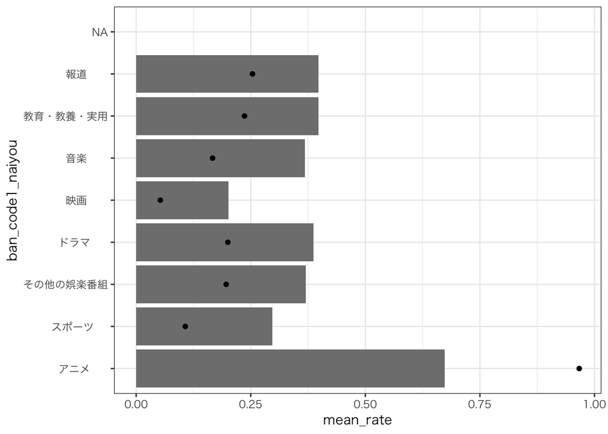

```r
orgn %>%
  filter(data_agg_type == 1) %>%
  select(program_code, program_start_time, watch_time) %>%
  left_join(program, by = c("program_code", "program_start_time")) %>%
  left_join(ban1, by = "ban_code1") %>%
  select(ban_code1_naiyou, watch_time, program_time) %>%
  mutate(rate = watch_time / program_time) %>%
  group_by(ban_code1_naiyou) %>%
  summarise(mean_rate = mean(rate),
            median_rate =median(rate)) %>%
  ggplot(aes(ban_code1_naiyou, mean_rate))+
  geom_bar(stat = "identity", fill = "gray50")+
  geom_point(aes(y = median_rate))+
  coord_flip()
```

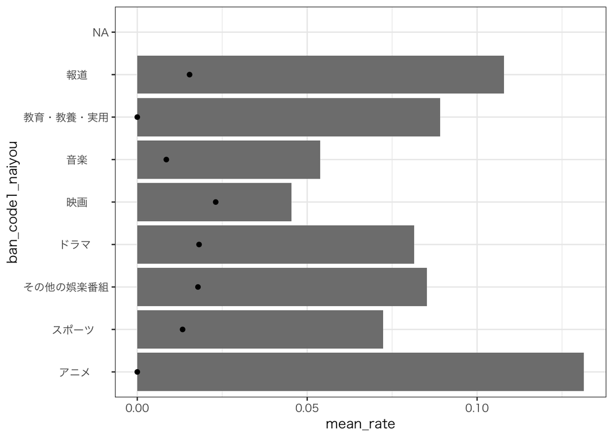

```r
orgn %>%
  filter(data_agg_type == 9) %>%
  select(program_code, program_start_time, watch_time) %>%
  left_join(program, by = c("program_code", "program_start_time")) %>%
  left_join(ban1, by = "ban_code1") %>%
  select(ban_code1_naiyou, watch_time, program_time) %>%
  mutate(rate = watch_time / program_time) %>%
  group_by(ban_code1_naiyou) %>%
  summarise(mean_rate = mean(rate),
            median_rate =median(rate)) %>%
  ggplot(aes(ban_code1_naiyou, mean_rate))+
  geom_bar(stat = "identity", fill = "gray50")+
  geom_point(aes(y = median_rate))+
  coord_flip()
```

# 6 per innovator

```r
innov <- prof %>%
  filter(qu_genre_code == 25,
         question_code == 4) %>%
  select(house_num, answer_code, answer)
```

## 6.1 sum watch_time

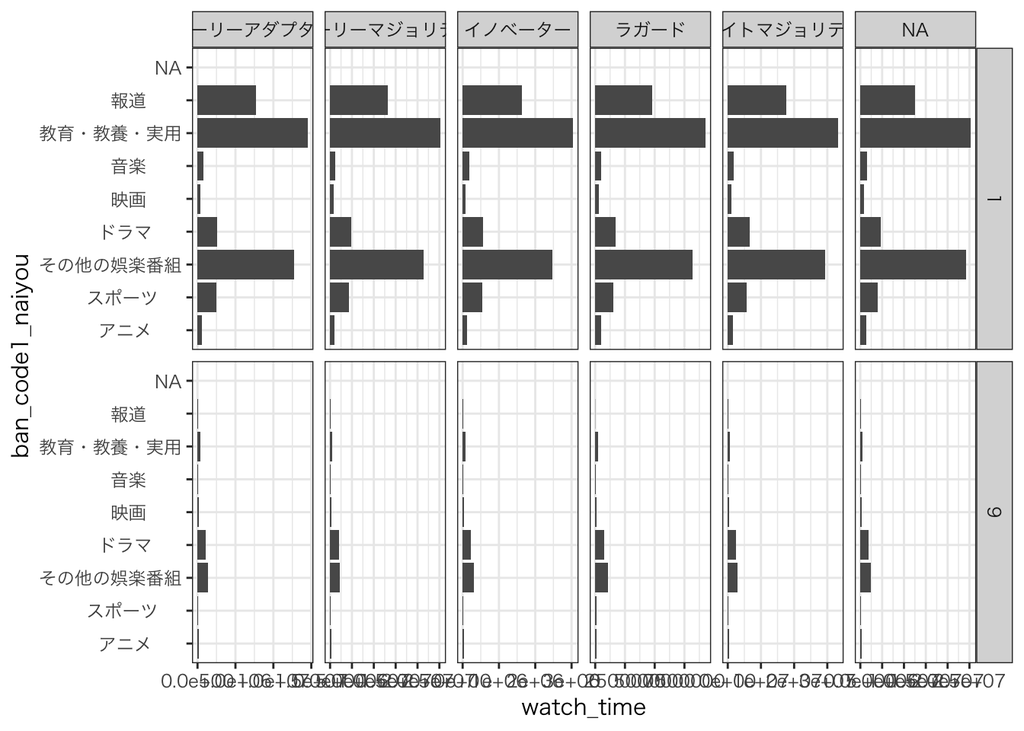

```r
orgn %>%
  select(house_num, program_code, program_start_time, data_agg_type, watch_time) %>%
  left_join(innov, by = "house_num") %>%
  left_join(program, by = c("program_code", "program_start_time")) %>%
  left_join(ban1, by = "ban_code1") %>%
  group_by(answer, ban_code1_naiyou, data_agg_type) %>%
  summarise(watch_time = sum(watch_time)) %>%
  collect() %>%
  ungroup() %>%
  mutate(answer = str_remove_all(answer, pattern = " ")) %>%
  ggplot(aes(ban_code1_naiyou, watch_time))+
  geom_bar(stat = "identity")+
  coord_flip()+
  facet_grid(data_agg_type~answer, scale = "free")
```